# Ejercicios ETL

Yader Coca

25 de abril de 2019

# 1- Modificar el setup del .Rmd para setear el archivo al proyecto

# 2- Levantar datos y guardar

Acceder a los datos de Vino (blanco o rojo) del repositorio de machine learning de UCI (https://archive.ics.uci.edu/ml/datasets/Wine+Quality) y guardar en el formato más eficiente, tomando en cuenta el tamaño y la velocidad de carga. Argumentar.

# Paquetes y Librerias

```
## here() starts at C:/Users/ycoca/Desktop/Taller Aprendizaje Automatico
```

[output not shown]

```
## [[1]]
## [1] FALSE
```

Levantar datos y guardar

```r
redWineDf <- read.csv2('Dataset/winequality-red.csv')
head(redWineDf)
```

```
##   fixed.acidity volatile.acidity citric.acid residual.sugar chlorides
## 1           7.4              0.7           0            1.9     0.076
## 2           7.8             0.88           0            2.6     0.098
## 3           7.8             0.76        0.04            2.3     0.092
## 4          11.2             0.28        0.56            1.9     0.075
## 5           7.4              0.7           0            1.9     0.076
## 6           7.4             0.66           0            1.8     0.075
##   free.sulfur.dioxide total.sulfur.dioxide density   pH sulphates alcohol
## 1                  11                   34  0.9978 3.51      0.56     9.4
## 2                  25                   67  0.9968  3.2      0.68     9.8
## 3                  15                   54   0.997 3.26      0.65     9.8
## 4                  17                   60   0.998 3.16      0.58     9.8
## 5                  11                   34  0.9978 3.51      0.56     9.4
## 6                  13                   40  0.9978 3.51      0.56     9.4
##   quality
## 1       5
## 2       5
## 3       5
## 4       6
## 5       5
## 6       5
```

```r
str(redWineDf)
```

```
## 'data.frame':    1599 obs. of  12 variables:
##  $ fixed.acidity       : Factor w/ 96 levels "10","10.1","10.2",..: 71 75 75 13 71 71 76 70 75 72 ...
##  $ volatile.acidity    : Factor w/ 143 levels "0.12","0.16",..: 77 113 89 13 77 69 57 67 53 42 ...
##  $ citric.acid         : Factor w/ 80 levels "0","0.01","0.02",..: 1 1 5 57 1 1 7 1 3 37 ...
##  $ residual.sugar      : Factor w/ 91 levels "0.9","1.2","1.3",..: 11 31 26 11 11 10 6 2 20 73 ...
##  $ chlorides           : Factor w/ 153 levels "0.012","0.034",..: 40 62 56 39 40 39 33 29 37 35 ...
##  $ free.sulfur.dioxide : Factor w/ 60 levels "1","10","11",..: 3 18 7 9 3 5 7 7 60 9 ...
##  $ total.sulfur.dioxide: Factor w/ 144 levels "10","100","101",..: 75 109 95 102 75 81 100 60 57 4 ...
##  $ density             : Factor w/ 436 levels "0.99007","0.9902",..: 343 272 288 355 343 343 240 101 272 343 ...
##  $ pH                  : Factor w/ 89 levels "2.74","2.86",..: 64 33 39 29 64 64 43 52 49 48 ...
##  $ sulphates           : Factor w/ 96 levels "0.33","0.37",..: 19 31 28 21 19 19 9 10 20 43 ...
##  $ alcohol             : Factor w/ 65 levels "10","10.0333333333333",..: 57 63 63 63 57 57 57 1 58 7 ...
##  $ quality             : int  5 5 5 6 5 5 5 7 7 5 ...
```

Distintos formatos para comparativa de tiempos y tamaños

```r
# Definir path
path_csv <- 'Datasets/df.csv'
path_feather <- 'Datasets/df.feather'
path_rdata <- 'Datasets/df.RData'
path_rds <- 'Datasets/df.rds'

# Guardo Objs
write.csv(redWineDf, file = path_csv, row.names = F)
write_feather(redWineDf, path_feather)
save(df, file = path_rdata)
saveRDS(df, path_rds)

# Tamaño de los objetos

files <- c('Datasets/df.csv', 'Datasets/df.feather', 'Datasets/df.RData', 'Datasets/df.rds')
info <- file.info(files)
info$size_mb <- info$size/(1024 * 1024)
print(subset(info, select = c("size_mb")))
```

```
##                          size_mb
## Datasets/df.csv     0.1153726578
## Datasets/df.feather 0.0867996216
## Datasets/df.RData   0.0003309250
## Datasets/df.rds     0.0003223419
```

```r
benchmark <- microbenchmark(readCSV = utils::read.csv(path_csv),
               readrCSV = readr::read_csv(path_csv, progress = F),
               fread = data.table::fread(path_csv, showProgress = F),
               loadRdata = base::load(path_rdata),
               readRds = base::readRDS(path_rds),
               readFeather = feather::read_feather(path_feather), times = 10)
print(benchmark, signif = 2)
```

```
## Unit: microseconds
##         expr   min    lq  mean median    uq    max neval cld
##      readCSV  6500  6900  7800   7400  8500  11000    10  ab
##     readrCSV 12000 12000 30000  14000 15000 170000    10   b
##        fread  2600  2600  3200   2900  3000   6300    10  ab
##    loadRdata   860  1000  1200   1100  1500   1700    10  a
##      readRds   470   490   760    740   960   1100    10  a
##  readFeather  2100  2100  3000   2500  3500   5300    10  ab
```

- Cargar el shape de códigos postales de Montevideo.

```r
  library(rgdal)
  sp_df <- readOGR(dsn = "cpost")
  print(sp_df)
```

[output not shown]

[output cut: 4937 more lines]

- ¿Qué clase de objeto es?

  ```r
    typeof(sp_df);
  ```

  ```
  ## [1] "S4"
  ```

- ¿Qué dimensión tiene?

  ```r
    length(sp_df);
  ```

  ```
  ## [1] 19
  ```

- Grafique.

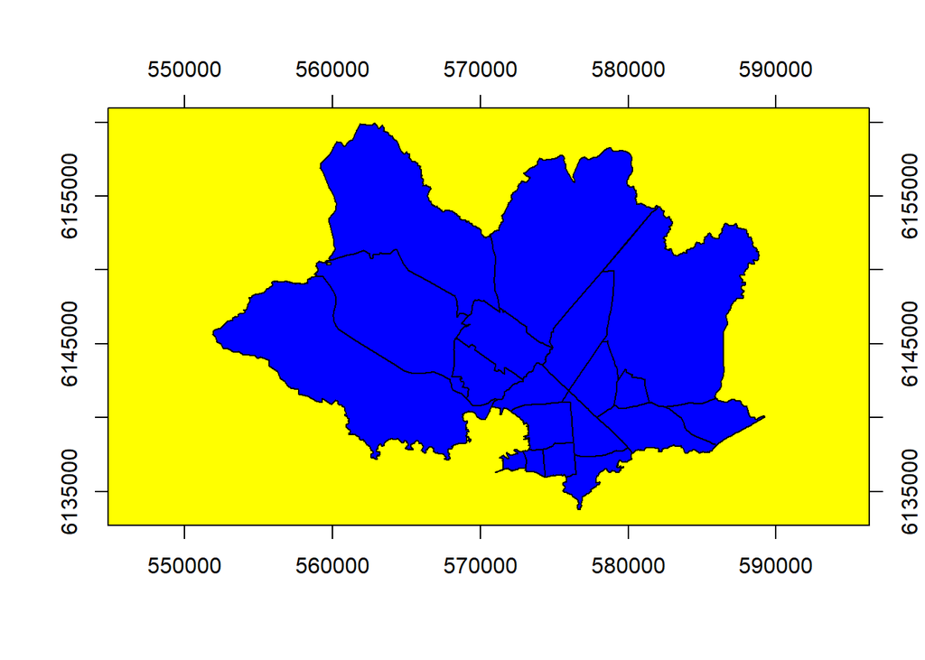

  ```r
    plot(sp_df, col='blue', bg='yellow')
    box()
    for(i in 1:4) axis(i)
  ```

- Muestre la estructura de la tabla de datos. ¿Considera que alguna variable tiene una clase o tipo de datos errónea

  ```r
    head(sp_df@data)
  ```

  ```
  ##   apis_id gid cent_enc site_code cod_postal poblacion codigo
  ## 0       1   1      110       CVJ      11000      9763  11000
  ## 1       2   2      111       CVJ      11100     31376  11100
  ## 2      50   3      112       COR      11200     78736  11200
  ## 3       4   4      113       POC      11300    101903  11300
  ## 4      41   5      114       PUN      11400    117804  11400
  ## 5      42   6      115       CAR      11500     28827  11500
  ```

  ```r
    sapply(sp_df@data, class)
  ```

  ```
  ##    apis_id        gid   cent_enc  site_code cod_postal  poblacion
  ##   "factor"   "factor"   "factor"   "factor"   "factor"   "factor"
  ##     codigo
  ##  "integer"
  ```

  ```r
    str(sp_df@data)
  ```

  ```
  ## 'data.frame':    19 obs. of  7 variables:
  ##  $ apis_id   : Factor w/ 19 levels "1","100","101",..: 1 10 15 11 12 13 14 16 18 3 ...
  ##  $ gid       : Factor w/ 19 levels "1","10","11",..: 1 11 13 14 15 16 17 18 19 2 ...
  ##  $ cent_enc  : Factor w/ 19 levels "110","111","112",..: 1 2 3 4 5 6 7 8 9 10 ...
  ##  $ site_code : Factor w/ 14 levels "ACA","AGU","BEL",..: 10 10 9 12 13 6 11 4 2 3 ...
  ##  $ cod_postal: Factor w/ 19 levels "11000","11100",..: 1 2 3 4 5 6 7 8 9 10 ...
  ##  $ poblacion : Factor w/ 19 levels "101903","110182",..: 19 7 14 1 3 5 16 11 17 13 ...
  ##  $ codigo    : int  11000 11100 11200 11300 11400 11500 11600 11700 11800 11900 ...
  ```

- ¿Todos los sitios (identificados por la variable site_code) tienen un único valor de código postal?

```r
head(sp_df@data)
```

```
##   apis_id gid cent_enc site_code cod_postal poblacion codigo
## 0       1   1      110       CVJ      11000      9763  11000
## 1       2   2      111       CVJ      11100     31376  11100
## 2      50   3      112       COR      11200     78736  11200
## 3       4   4      113       POC      11300    101903  11300
## 4      41   5      114       PUN      11400    117804  11400
## 5      42   6      115       CAR      11500     28827  11500
```

```r
#which
#length(unique(sp_df$cod_postal))
#length(unique(sp_df$site_code))
#caracter <- unique(sp_df$site_code, incomparables = FALSE, fromLast = FALSE,
#        nmax = 1)

paste("Hay ", length(unique(sp_df$cod_postal)) - length(unique(sp_df$site_code)), " que tienen valor unico")
```

```
## [1] "Hay  5  que tienen valor unico"
```

# 3- Crear un dataframe

```r
poblaciones_df <- data.frame(
  pais = c('Argentina ', 'Argentina ', 'Uruguay ', 'Uruguay ','Argentina ', 'Argentina ', 'Uruguay ', 'Uruguay '),
  Anio = c(1980,1980,1980,1980,1981,1981,1981,1981),
  tipo = c('total', 'urbana', 'total', 'urbana'),
  poblacion = c(27000000,23000000,3000000,200000,27000100,23000030,3000001,200000)
)

poblacion_ordenado <- tidyr::spread(data = poblaciones_df, key = tipo, value = poblacion)
```

## 3.1 - Crear un id

La función *seq* permite general un vector secuencial de acuerdo a determinada regla. Por ejemplo es posible crear un id:

```r
id <- seq(1, 1000, 1)
```

- Explique cada uno de los argumentos de la función de arriba.

la funcion seq puede contar hasta con 3 argumentos seq(from, to, length.out= ) *from: valor inicial de la secuencia* to: valor final de la secuencia *by: incremento en la secuencia

- ¿Qué tipo de objetido es id en R? ¿Cuál es el largo del mismo? ¿Cuál es la clase? ¿Cuál es el tipo?

Tipo de objeto  
R:Vector, cadenas unidimensionales (es decir una sola columna o fila) de un tipo único de valores (numéricos, caracteres, etc.)

```r
mode(id)
```

```
## [1] "numeric"
```

Tipo de clase

```r
class(id)
```

```
## [1] "numeric"
```

Largo

```r
length(id)
```

```
## [1] 1000
```

Tipo de de dato

```r
typeof(id)
```

```
## [1] "double"
```

- ¿Cuál es la diferencia entre esta clase y tipo?

Tipo -> mutuamente excluyente de acuerdo con su estructura basica. Modos atomicos son numeric,complex, character y logical. Clase -> Propiedad asignada a un objeto que determina como funcionan las funciones genericas con el. No es mutuamente excluyente. SI un objeto no tiene asignada una clase especifica entonces es la misma que su modo.

- Proponga un id con una secuencia diferente.

```r
id2 <- seq(10, 100, 2)
id2
```

```
##  [1]  10  12  14  16  18  20  22  24  26  28  30  32  34  36  38  40  42
## [18]  44  46  48  50  52  54  56  58  60  62  64  66  68  70  72  74  76
## [35]  78  80  82  84  86  88  90  92  94  96  98 100
```

## 3.2 - Crear otros vectores.

- Cree un vector con dos valores para definir el género de una persona (femenino y masculino).

```r
vGenero <- seq(1, 2, 1)
vGenero
```

```
## [1] 1 2
```

- Cree un vector secuencial para definir una variable edad que comience en 18, termine en 60 y vaya de a un año.

```r
edad <- seq(18, 60, 1)
edad
```

```
##  [1] 18 19 20 21 22 23 24 25 26 27 28 29 30 31 32 33 34 35 36 37 38 39 40
## [24] 41 42 43 44 45 46 47 48 49 50 51 52 53 54 55 56 57 58 59 60
```

- Cree un vector caracter con los sitios (únicos) de los códigos postales. Recuerde que la función unique devuelve valores únicos sin duplicados.

```r
caracter <- unique(sp_df$site_code, incomparables = FALSE)
caracter
```

```
##  [1] CVJ COR POC PUN CAR LAH BRZ AGU BEL UNI ACA CLN CER BVQ
## Levels: ACA AGU BEL BRZ BVQ CAR CER CLN COR CVJ LAH POC PUN UNI
```

- Cree un vector de tiendas con los nombres como letras desde A hasta J, hágalos manual y con la función LETTERS

```r
tiendas <- LETTERS[1:10]
tiendas
```

```
##  [1] "A" "B" "C" "D" "E" "F" "G" "H" "I" "J"
```

## 3.3 - Crear muestras de datos

La función *sample* “takes a sample of the specified size from the elements of x using either with or without replacement”.

Cree vectores de largo 1000 a través de muestra de los anteriores vectores (género, edad, sitios, tiendas), de 1000 con reemplazo.

```r
v1 <- sample(vGenero, 1000, replace = TRUE)
v1
```

```
##    [1] 2 1 2 2 2 2 2 1 2 1 1 1 1 1 1 1 1 1 1 2 2 2 2 1 2 1 2 2 1 2 1 1 2 2
##   [35] 2 2 2 2 2 1 1 1 2 2 2 1 2 1 2 2 1 2 2 1 2 2 1 2 2 2 2 1 1 2 2 1 2 2
##   [69] 2 1 2 1 2 2 1 2 2 1 1 1 2 1 2 2 1 1 1 1 2 2 1 1 1 2 2 1 2 1 2 1 1 1
##  [103] 2 2 1 2 1 2 1 2 1 2 2 1 2 2 1 2 1 2 1 2 2 2 2 2 1 2 2 2 1 2 2 2 2 2
##  [137] 1 2 2 1 2 2 1 1 1 1 1 2 2 2 2 2 2 2 1 1 1 2 1 2 1 1 1 1 1 1 1 2 1 2
##  [171] 1 1 1 1 2 2 1 2 2 2 1 2 2 2 1 1 2 1 1 1 1 1 2 1 2 1 1 1 1 1 2 2 1 1
##  [205] 2 1 2 2 1 2 2 2 2 2 1 1 1 2 2 2 2 1 2 2 1 2 1 1 2 1 1 1 1 2 1 2 1 2
##  [239] 1 2 1 2 2 1 2 2 1 1 2 2 2 1 2 2 1 2 1 2 1 1 2 1 2 2 2 1 1 1 2 1 1 1
##  [273] 1 2 2 1 2 1 2 1 1 1 2 2 1 1 2 2 2 1 1 1 2 1 2 2 1 1 2 1 1 1 2 2 2 1
##  [307] 1 2 2 2 1 2 1 2 1 1 2 1 2 1 1 1 1 1 2 1 1 1 1 1 1 2 1 1 2 1 1 2 2 1
##  [341] 1 2 1 2 1 1 1 2 1 1 1 2 2 1 1 2 2 1 1 1 2 1 2 2 2 2 2 2 1 2 2 2 2 1
##  [375] 2 1 1 1 1 2 1 2 2 2 1 1 2 2 2 1 1 2 1 2 2 1 1 1 2 1 1 1 2 2 2 2 1 2
##  [409] 2 1 2 1 2 1 1 1 1 2 2 1 2 1 1 1 1 2 1 1 1 2 2 1 2 1 2 2 1 1 2 2 1 1
##  [443] 1 1 2 2 1 1 1 1 1 2 2 1 1 2 1 1 2 1 1 2 1 1 2 2 2 2 2 1 1 1 1 1 1 2
##  [477] 2 1 2 1 2 2 1 1 1 2 1 2 2 1 1 1 1 1 1 1 2 2 2 1 2 2 1 1 1 2 2 2 2 2
##  [511] 1 2 2 1 2 2 1 2 2 1 2 2 2 1 2 2 2 2 2 2 1 1 1 2 2 2 2 1 1 1 2 2 1 2
##  [545] 2 2 2 2 2 1 2 1 2 2 2 1 1 2 2 2 2 2 2 1 2 2 1 1 2 2 2 2 2 1 1 2 2 1
##  [579] 1 2 1 1 2 1 1 2 1 2 2 1 2 1 1 1 1 1 2 1 2 2 2 2 1 2 2 1 2 2 1 1 1 1
##  [613] 2 2 2 2 2 1 2 2 1 1 1 1 1 1 1 1 1 2 2 2 2 2 1 2 1 2 1 1 2 1 1 1 1 1
##  [647] 1 1 1 2 2 1 1 1 1 1 2 1 1 2 1 1 2 1 2 2 1 1 2 2 1 1 2 1 1 2 2 2 1 2
##  [681] 1 1 1 2 2 2 1 1 2 2 2 1 2 2 2 2 1 2 2 2 1 2 1 2 2 1 2 1 2 2 2 2 2 2
##  [715] 2 1 2 1 2 2 1 1 2 1 2 2 2 1 1 2 2 2 2 2 1 1 1 1 2 2 2 1 1 1 1 1 1 1
##  [749] 2 2 2 1 2 1 2 2 2 1 1 1 1 1 1 1 1 2 2 2 2 1 1 2 2 2 1 1 2 1 2 1 1 1
##  [783] 1 1 1 1 1 1 2 2 1 2 1 1 1 1 1 1 2 2 2 2 2 1 2 1 1 1 1 2 1 2 2 2 2 1
##  [817] 1 1 1 1 1 1 2 1 2 1 1 1 1 2 2 2 1 1 2 1 1 2 1 1 1 1 2 2 2 1 1 1 1 2
##  [851] 2 2 2 2 1 2 1 2 1 2 2 1 1 1 1 1 1 2 2 2 2 2 1 2 1 2 2 2 1 1 2 2 1 1
##  [885] 1 1 1 2 2 1 2 1 2 2 2 1 2 2 2 2 1 1 2 2 2 2 1 2 1 2 1 2 2 1 2 2 1 1
##  [919] 2 2 2 2 2 1 1 1 1 2 2 2 1 1 2 2 2 2 2 1 2 1 2 1 1 1 1 2 1 2 1 1 2 1
##  [953] 2 1 1 2 2 1 1 2 2 1 1 1 1 2 1 2 2 2 1 2 1 2 2 2 2 2 1 1 1 1 1 2 2 2
##  [987] 1 2 2 1 1 2 1 2 1 2 1 2 1 2
```

```r
v2 <- sample(edad, 1000, replace = TRUE)
v2
```

```
##    [1] 59 41 44 51 46 50 38 28 25 47 55 26 34 21 32 35 53 26 34 33 31 29 50
##   [24] 31 57 30 37 32 41 23 19 56 30 59 39 29 40 26 32 54 41 49 60 34 50 27
##   [47] 37 23 30 45 36 19 33 48 27 23 22 28 46 44 45 22 20 43 34 58 38 50 41
##   [70] 46 49 34 54 38 33 55 39 20 18 30 23 41 35 55 36 52 37 37 53 53 53 22
##   [93] 51 59 20 50 48 22 21 41 26 22 27 30 58 28 60 26 51 19 28 34 19 18 19
##  [116] 27 39 51 38 53 38 50 28 46 45 32 22 52 19 57 52 30 60 23 38 57 32 46
##  [139] 58 27 23 42 23 33 60 45 54 23 27 42 58 43 38 52 57 48 56 18 58 56 34
##  [162] 41 18 19 58 21 40 20 49 36 53 52 42 60 37 26 55 57 43 53 51 47 47 29
##  [185] 49 24 39 56 49 58 57 41 21 22 36 35 58 49 47 46 30 40 37 18 53 46 58
##  [208] 59 37 47 60 24 22 20 37 18 49 58 42 39 27 51 60 40 34 54 58 18 36 28
##  [231] 50 45 57 26 27 33 50 36 41 36 20 47 20 22 49 28 46 41 24 23 59 40 23
##  [254] 26 31 30 29 54 31 33 22 51 43 30 21 33 21 20 24 44 38 27 39 32 29 35
##  [277] 33 21 26 49 57 44 47 45 47 54 25 52 26 41 28 55 28 59 56 45 55 22 20
##  [300] 60 38 46 37 39 32 49 23 20 29 50 59 53 49 22 30 39 39 30 30 39 45 44
##  [323] 22 26 28 28 48 55 50 53 38 46 19 25 49 34 26 36 38 27 49 37 39 19 25
```

[output cut: 29 more lines]

```r
v3 <- sample(sp_df$site_code, 1000, replace = TRUE)
v3
```

```
##    [1] BVQ CER BEL BRZ PUN BEL BEL BVQ AGU CAR CLN CER BEL POC BRZ CAR CLN
##   [18] AGU PUN CER CVJ BEL BVQ AGU UNI PUN CLN BVQ POC CLN BEL LAH AGU BEL
##   [35] UNI BEL BEL POC CER CLN CLN ACA PUN BEL CVJ BRZ CLN UNI UNI POC CVJ
##   [52] BEL BEL BEL POC CVJ BEL LAH CER CVJ UNI CLN ACA BVQ BEL CLN CVJ COR
##   [69] LAH BEL BVQ CLN BEL POC CVJ CLN UNI CLN CER BEL CER PUN CLN UNI UNI
##   [86] CVJ AGU COR BVQ CAR BEL CLN POC PUN CVJ UNI BEL CLN PUN UNI UNI LAH
##  [103] LAH CVJ CER LAH CAR BEL BRZ CVJ PUN BVQ BEL BVQ CAR AGU UNI CVJ CVJ
##  [120] CLN CAR COR BEL ACA CVJ CER CVJ BEL UNI AGU CLN ACA ACA COR PUN COR
##  [137] CLN BRZ BVQ COR COR UNI BVQ BEL PUN BEL BEL UNI PUN UNI UNI PUN COR
##  [154] UNI CVJ PUN BRZ BRZ BEL BEL UNI BEL PUN POC CER COR ACA COR BEL COR
##  [171] CAR CAR CLN CVJ CVJ BEL BEL COR CVJ BRZ CVJ LAH BVQ UNI CAR AGU LAH
##  [188] AGU BEL UNI COR CAR CVJ CAR BVQ PUN COR BVQ CVJ POC CVJ POC PUN CVJ
##  [205] BEL CLN BRZ BEL BVQ BEL UNI CLN BEL BRZ UNI BEL ACA CAR BEL PUN CVJ
##  [222] CLN AGU BEL CLN BVQ BEL POC CLN AGU AGU CER BEL POC BRZ CVJ CVJ CER
##  [239] ACA CLN CAR BEL BEL AGU CVJ BRZ CVJ BRZ UNI UNI CLN BVQ CVJ AGU CVJ
```

[output cut: 45 more lines]

```r
v4 <- sample(tiendas, 1000, replace = TRUE)
v4
```

```
##    [1] "I" "I" "C" "H" "B" "D" "H" "B" "H" "E" "H" "F" "E" "C" "D" "G" "C"
##   [18] "I" "A" "A" "D" "G" "H" "B" "F" "H" "D" "E" "I" "B" "C" "A" "A" "I"
##   [35] "I" "E" "B" "H" "G" "A" "G" "F" "E" "A" "F" "H" "F" "B" "D" "A" "G"
##   [52] "B" "J" "G" "H" "A" "C" "D" "G" "H" "D" "I" "A" "H" "G" "D" "E" "D"
##   [69] "I" "E" "G" "J" "H" "A" "E" "G" "E" "A" "B" "A" "A" "D" "F" "D" "I"
##   [86] "F" "G" "C" "I" "D" "A" "E" "E" "C" "D" "J" "A" "C" "I" "E" "C" "D"
##  [103] "H" "C" "G" "G" "A" "J" "J" "E" "G" "H" "G" "A" "C" "G" "E" "D" "J"
##  [120] "C" "D" "C" "A" "H" "A" "C" "A" "E" "H" "H" "D" "A" "C" "D" "I" "E"
##  [137] "D" "G" "G" "B" "A" "J" "I" "I" "E" "J" "E" "G" "E" "E" "D" "C" "C"
##  [154] "J" "D" "A" "A" "E" "B" "A" "J" "A" "G" "E" "I" "H" "J" "J" "F" "F"
##  [171] "E" "D" "H" "I" "A" "J" "F" "H" "E" "H" "G" "I" "B" "C" "F" "C" "H"
##  [188] "A" "F" "F" "I" "E" "G" "G" "B" "G" "B" "H" "D" "F" "I" "A" "A" "C"
##  [205] "F" "E" "A" "C" "H" "J" "D" "H" "I" "D" "H" "F" "J" "C" "C" "J" "H"
##  [222] "H" "D" "F" "H" "D" "E" "D" "D" "D" "E" "D" "I" "D" "A" "D" "A" "I"
##  [239] "I" "F" "H" "J" "J" "D" "H" "A" "H" "D" "D" "D" "H" "I" "D" "I" "E"
```

[output cut: 44 more lines]

## 3.4 - Generar el dataframe de los clientes

Cree un dataframe de 1000 filas y cuatro columnas. Donde: * El nombre sea “clientes”. * Las 4 columnas incluran: id, sexo, edad y barrios * No genere los strings como factores

```r
id <- c(1,2,3,4)
sexo <- c('M', 'M', 'M','F')
edad <- c('30', '63', '43','32')
barrios<- c('Centro', 'Pocitos', 'Malvin','Punta Gorda')
clientes <- data.frame(id,sexo,edad ,barrios, nrow = 1000 ,stringsAsFactors = FALSE)
x <- c('id', 'sexo', 'edad','barrios')
colnames(clientes) <- x
str(clientes)
```

```
## 'data.frame':    4 obs. of  5 variables:
##  $ id     : num  1 2 3 4
##  $ sexo   : chr  "M" "M" "M" "F"
##  $ edad   : chr  "30" "63" "43" "32"
##  $ barrios: chr  "Centro" "Pocitos" "Malvin" "Punta Gorda"
##  $ NA     : num  1000 1000 1000 1000
```